# Reproducable Research Project for Week 2

Kevin Parent

04/09/2019

We will begin with a few premliminaries.

```r
rm(list=ls(all=T))  # Clear anything in memory
options(scipen=999) # Disable scientific notation
library(ggplot2)
```

Now we download the data and unzip it, loading it into the variable x.

```r
if(!file.exists('./Data-JH')){dir.create("./data")}
fileUrl<-'https://d396qusza40orc.cloudfront.net/repdata%2Fdata%2Factivity.zip'
download.file(fileUrl,destfile="./Data-JH/Dataset.zip",method="curl")

unzip(zipfile='./Data-JH/Dataset.zip',exdir='./Data-JH/UCI_HAR_Dataset')
data.path <- dir('./Data-JH/UCI_HAR_Dataset',full.names=T)

x<-read.csv(data.path)
```

The data looks good, and there is no need to tidy it up or change anything at this point.

```r
head(x)
```

```
##   steps       date interval
## 1    NA 2012-10-01        0
## 2    NA 2012-10-01        5
## 3    NA 2012-10-01       10
## 4    NA 2012-10-01       15
## 5    NA 2012-10-01       20
## 6    NA 2012-10-01       25
```

Now we create a histogram of the variable steps.

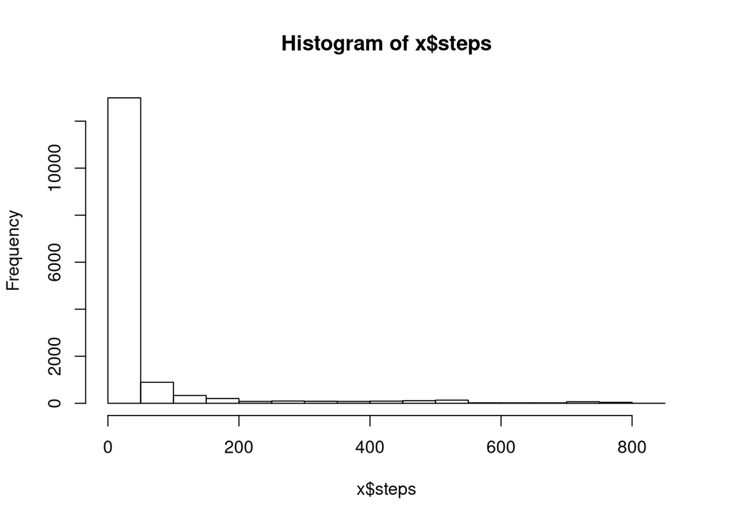

```r
hist(x$steps)
```

Next, we check the mean and median of this variable. Since the median is 0 even with the NAs removed, we perform a summary just to double check.

```r
mean(x$steps, na.rm=T)
```

```
## [1] 37.3826
```

```r
median(x$steps, na.rm=T)
```

```
## [1] 0
```

```r
summary(x$steps)
```

```
##    Min. 1st Qu.  Median    Mean 3rd Qu.    Max.    NA's
##    0.00    0.00    0.00   37.38   12.00  806.00    2304
```

Now we want to plot a time series plot of the average number of steps taken on each day. There are several ways this can be done, but here we will calculate the means separately and plot them.

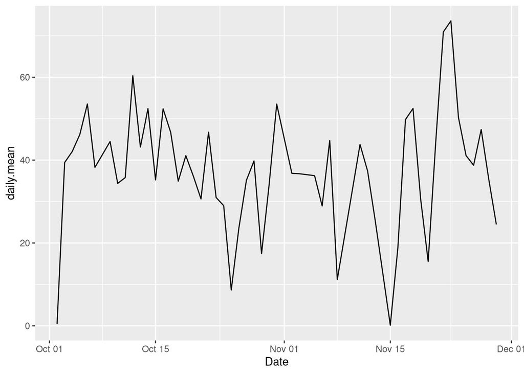

```r
daily.mean<-tapply(x$steps,INDEX=x$date,FUN=mean)
Date<-unique(as.Date(x$date))

mean.dates<-data.frame(Date,daily.mean,row.names=NULL)
mean.dates<-mean.dates[complete.cases(mean.dates),] #remove NAs
ggplot(mean.dates,aes(Date,daily.mean)) +
    geom_line()
```

Our next step is to see which interval, on average, contains the most number of steps.

```r
mean.by.interval<-tapply(x$steps,INDEX=x$interval,FUN=mean,na.rm=TRUE)
names(which.max(mean.by.interval))
```

```
## [1] "835"
```

Now we need to address the missing values. We impute them here by taking the average of the given interval.

```r
imputed<-x
NAs<-which(!complete.cases(x)) #rows with NAs

for(i in NAs){
    steps.at.current.interval<-unlist(subset(imputed,interval==imputed$interval[i])[1]) #all data for this interval (steps only)
    current.interval.mean.steps<-mean(steps.at.current.interval,na.rm=TRUE) #mean of those steps
    imputed[i,1]<-current.interval.mean.steps #replace the NA with this mean
}
head(imputed)
```

```
##       steps       date interval
## 1 1.7169811 2012-10-01        0
## 2 0.3396226 2012-10-01        5
## 3 0.1320755 2012-10-01       10
## 4 0.1509434 2012-10-01       15
## 5 0.0754717 2012-10-01       20
## 6 2.0943396 2012-10-01       25
```

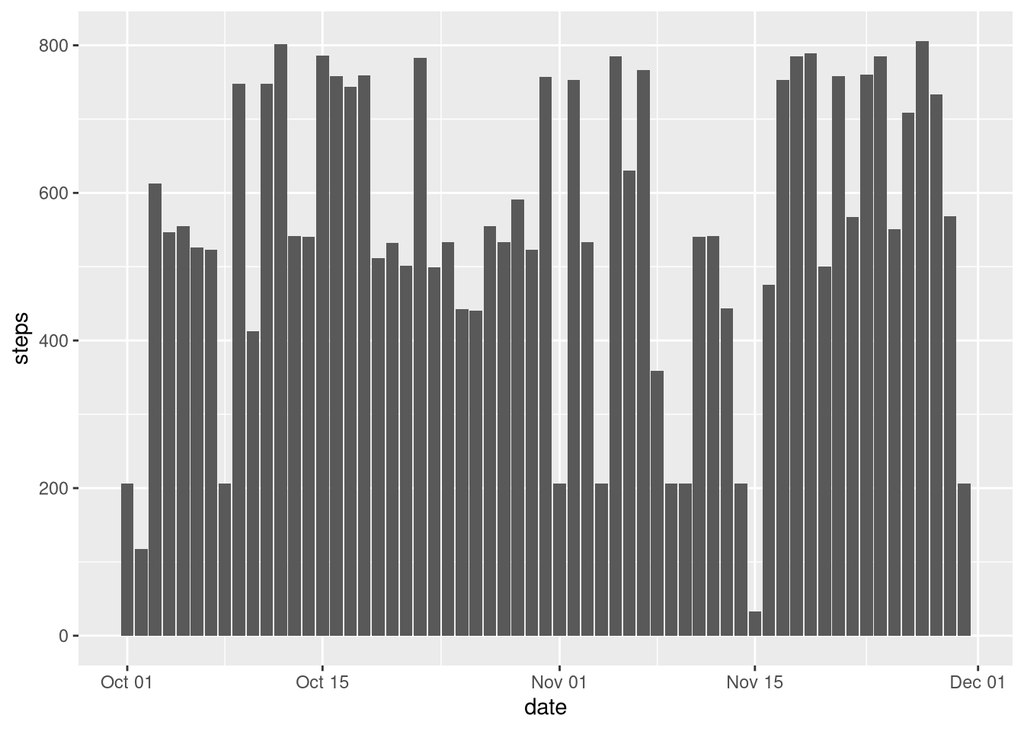

```r
imputed$date<-as.Date(imputed$date)

ggplot(imputed,aes(date,steps)) +
    geom_bar(stat = "identity", position = "dodge")
```

Next we will compare of steps taken on weekdays versus the weekend. First we need to make a new factor collapsing Saturday and Sunday into ‘weekend’ and the rest into ‘weekday’.

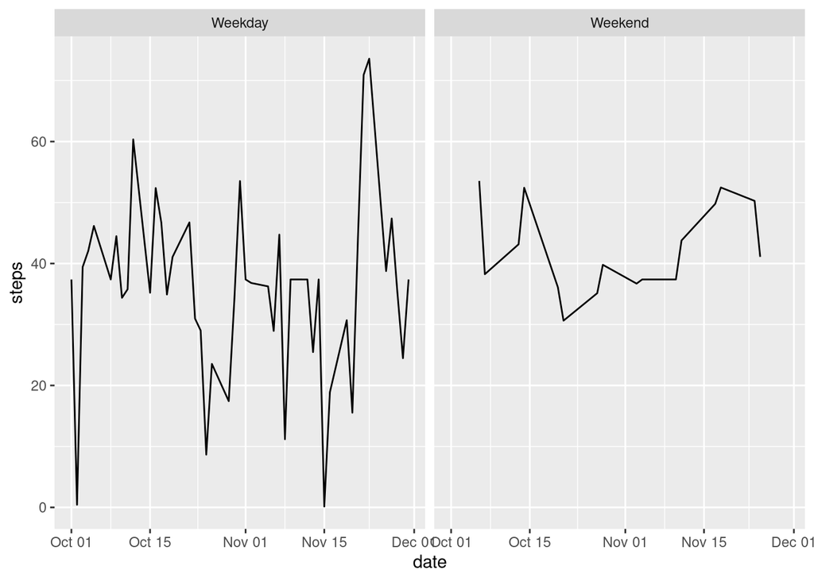

```r
days<-as.factor(weekdays(imputed$date))
weekday<-ifelse(days=='Saturday' | days=='Sunday','Weekend','Weekday')
imputed<-data.frame(imputed,weekday)

ggplot(imputed,aes(date,steps)) +
    geom_line(stat='summary',fun.y='mean')+
    facet_grid(.~weekday)
```

We can see there is much less variation in the weekend data.